# Andaconda

Starting by launching Anaconda. Now Anaconda is an **environment** manager. That means you can make different 'installations' of python and all the various libraries, each isolated into its own environment. This is really nice for code hygene, as incompatible sets of libraries can be isolated from each other.

So from inside Anaconda, go to the Environments side tab and create a new phython 3 environment for this class. You will then want to install some common base libraries within this environment, including **numpy, matplotlib**, and **scipy**. Do this by listing the Any libraries, searching by name, selecting for installation and clicking apply.

## JupyterLab or jupyter notebook

At this point, go back to Home (in lefthand tabs), and make sure your new environment is selected. Then click on the JupyterLab (or jupyter notebook) Launch button (hitting install if needed). JupyterLab and jupyter notebooks are very closely related—they are really just different interfaces to the same underlying notebooks. Pick whichever you like. If that opens a new window in your web browser, you are in luck and go to the next step. If not, some debugging may be in order. Try going back to Environments, hit the triangle next to your environment, and launch a terminal. From there type `jupyter notebook`. If that doesn't work, more online trouble shooting will be needed.

> I also had issues getting the default directory to be somewhere sensible for me. This ended up getting me there https://github.com/jupyterlab/jupyterlab/issues/2980

## New notebook

In either environment, you see the list of notebooks. To actually start a notebook find the New command (button upper right in notebooks; File menu->New for JupyterLab), and select python 3. This should open a new Notebook. Make sure to save it with a name. You'll want a new notebook for every homework assignment and Lab.

## imports

Now import the libraries you will want to use, using `as` to shorten the names as desired. Note you need to have the `%matplotlib inline` first.

```python
%matplotlib inline
import numpy as np
import matplotlib
import matplotlib.pyplot as plt
import scipy
from scipy import stats

#this sets the size of the plot to something useful
plt.rcParams["figure.figsize"] = (20,15)
```

## Simple statistics

```python
d = stats.norm.rvs(loc = 5., scale = 0.01, size = 100000)
```

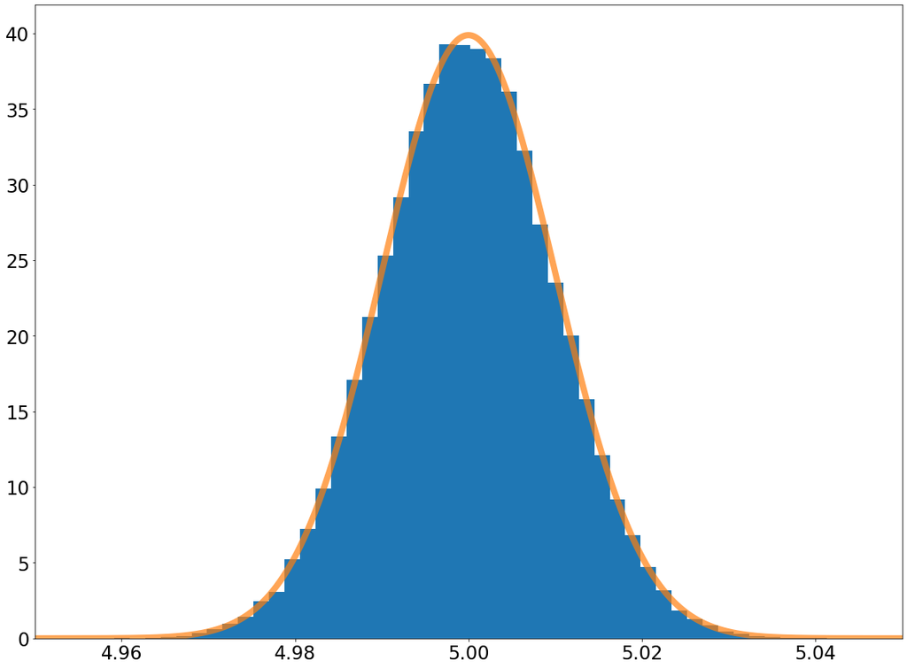

```python
fig, ax = plt.subplots(1, 1)
ax.hist(d,50, density=True)
plt.tick_params(labelsize = 24)
plt.xlim([4.95,5.05])
x = np.linspace(4.95,5.05,1000)
ax.plot(x,stats.norm.pdf(x,loc = 5., scale = 0.01),linewidth = 8,alpha = 0.7)
plt.show()
```

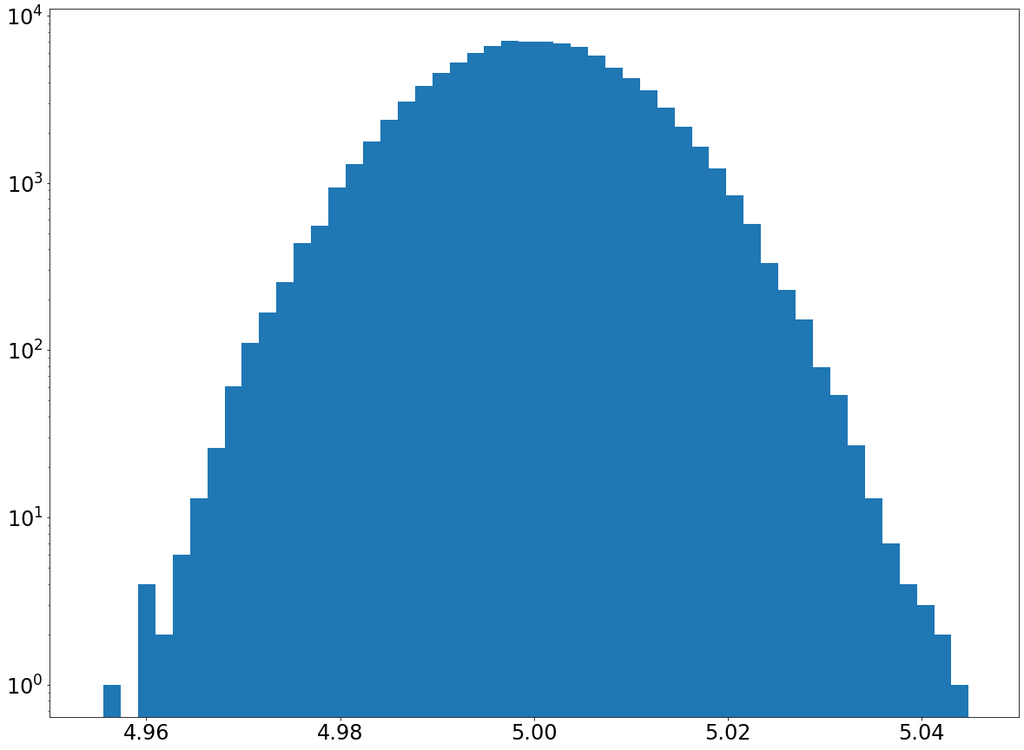

```python
ax = plt.hist(d,50)
plt.yscale('log')
plt.tick_params(labelsize = 24)
plt.xlim([4.95,5.05])
plt.show()
```

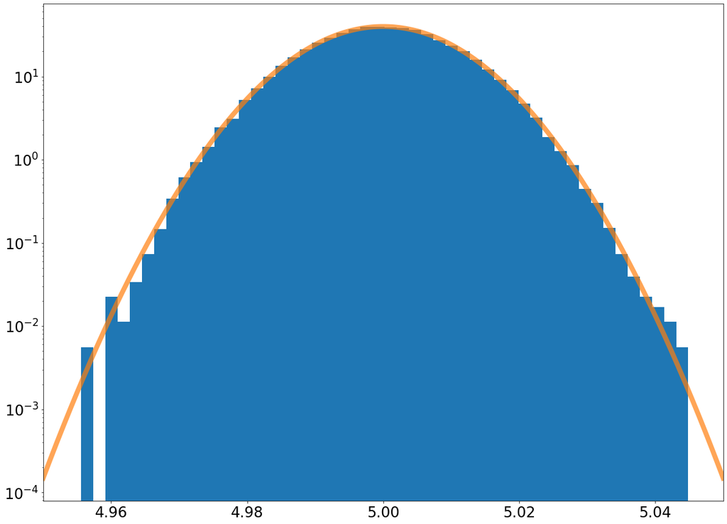

```python
fig, ax = plt.subplots(1, 1)
ax.hist(d,50, density=True)
plt.yscale('log')
plt.tick_params(labelsize = 24)
plt.xlim([4.95,5.05])
x = np.linspace(4.95,5.05,1000)
ax.plot(x,stats.norm.pdf(x,loc = 5., scale = 0.01),linewidth = 8,alpha = 0.7)
plt.show()
```